# Pertemuan 3

# Packages

```r
library(dLagM)
library(dynlm)
library(MLmetrics)
library(lmtest)
library(car)
library(readr)
```

# Import Data

Data yang digunakan berasal dari air quality New Delhi dengan peubah Y yaitu AQI (Air Quality Index) dan peubah X yaitu SO2

```r
dt <- read_csv("~/Kuliah/Semester 5/MPDW/NewDelhi_Air_quality.csv")
```

```
## ──────────────────────────────────────────────────────── Delimiter: "," chr
## (1): datetime dbl (9): ...1, AQI, CO, no2, o3, pm10, pm25, so2, ts dttm (2):
## timestamp_local, timestamp_utc
```

```r
dt
```

```
## # A tibble: 72 × 12
##     ...1   AQI    CO datetime    no2    o3  pm10  pm25   so2 timestamp_local
##    <dbl> <dbl> <dbl> <chr>     <dbl> <dbl> <dbl> <dbl> <dbl> <dttm>
##  1     0  30.2  199. 2022-10… 0.0469  55.8 10.5   5.64 0.387 2022-10-21 23:00:00
##  2     1  28.2  198. 2022-10… 0.0465  54.9 10.7   4.62 0.410 2022-10-22 00:00:00
##  3     2  26.6  199. 2022-10… 0.0469  54.6 11.2   3.52 0.402 2022-10-22 01:00:00
##  4     3  25    202. 2022-10… 0.0482  55.1 11.1   2.23 0.376 2022-10-22 02:00:00
##  5     4  26    205. 2022-10… 0.0489  55.8 10.4   1.98 0.339 2022-10-22 03:00:00
##  6     5  26    209. 2022-10… 0.0502  56.5  9.40  1.79 0.313 2022-10-22 04:00:00
##  7     6  26    209. 2022-10… 0.0502  55.8  8.48  1.75 0.313 2022-10-22 05:00:00
##  8     7  24    205. 2022-10… 0.0502  52.9  7.59  1.86 0.343 2022-10-22 06:00:00
##  9     8  23    200. 2022-10… 0.0469  50.1  7.64  2.21 0.395 2022-10-22 07:00:00
## 10     9  24    197. 2022-10… 0.0442  51.5  8.49  2.48 0.428 2022-10-22 08:00:00
## # ℹ 62 more rows
## # ℹ 2 more variables: timestamp_utc <dttm>, ts <dbl>
```

Pengubahan nama kolom AQI menjadi Yt dan so2 menjadi Xt

```r
library(dplyr)
data <- dt %>%
  rename(
    Yt = AQI,
    Xt = so2
  )

head(data)
```

```
## # A tibble: 6 × 12
##    ...1    Yt    CO datetime     no2    o3  pm10  pm25    Xt timestamp_local
##   <dbl> <dbl> <dbl> <chr>      <dbl> <dbl> <dbl> <dbl> <dbl> <dttm>
## 1     0  30.2  199. 2022-10-… 0.0469  55.8 10.5   5.64 0.387 2022-10-21 23:00:00
## 2     1  28.2  198. 2022-10-… 0.0465  54.9 10.7   4.62 0.410 2022-10-22 00:00:00
## 3     2  26.6  199. 2022-10-… 0.0469  54.6 11.2   3.52 0.402 2022-10-22 01:00:00
## 4     3  25    202. 2022-10-… 0.0482  55.1 11.1   2.23 0.376 2022-10-22 02:00:00
## 5     4  26    205. 2022-10-… 0.0489  55.8 10.4   1.98 0.339 2022-10-22 03:00:00
## 6     5  26    209. 2022-10-… 0.0502  56.5  9.40  1.79 0.313 2022-10-22 04:00:00
## # ℹ 2 more variables: timestamp_utc <dttm>, ts <dbl>
```

# Pembagian Data

```r
train<-data[0:57,]
test<-data[58:71,]
```

```r
train.ts<-ts(train)
test.ts<-ts(test)
data.ts<-ts(data)
```

# Model Koyck

$$y_t=a(1-\lambda)+\beta_0X_t+\beta_1Z_t+\lambda Y_{t-1}+V_t$$

dengan
$$V_t=u_t-\lambda
u_{t-1}$$

## Pemodelan

```r
model.koyck <- koyckDlm(x = train$Xt, y = train$Yt)
summary(model.koyck)
```

```
##
## Call:
## "Y ~ (Intercept) + Y.1 + X.t"
##
## Residuals:
##      Min       1Q   Median       3Q      Max
## -2.03389 -0.64933  0.06714  0.59821  2.27449
##
## Coefficients:
##             Estimate Std. Error t value Pr(>|t|)
## (Intercept)  2.65074    3.25695   0.814    0.419
## Y.1          0.89806    0.07378  12.171   <2e-16 ***
## X.t          0.09810    4.59272   0.021    0.983
## ---
## Signif. codes:  0 '***' 0.001 '**' 0.01 '*' 0.05 '.' 0.1 ' ' 1
##
## Residual standard error: 0.9316 on 53 degrees of freedom
## Multiple R-Squared: 0.8176,  Adjusted R-squared: 0.8108
## Wald test: 118.9 on 2 and 53 DF,  p-value: < 2.2e-16
##
## Diagnostic tests:
## NULL
##
##                             alpha       beta       phi
## Geometric coefficients:  26.00265 0.09809751 0.8980589
```

```r
AIC(model.koyck)
```

```
## [1] 155.8998
```

```r
BIC(model.koyck)
```

```
## [1] 164.0012
```

Dari hasil tersebut, diperoleh bahwa peubah $x_t$ memiliki nilai $p\text{-value} > 0.05$, sedangkan peubah $y_{t-1}$ memiliki nilai $p\text{-value} < 0.05$. Hal ini menunjukkan bahwa peubah $x_t$ **tidak berpengaruh signifikan** terhadap $y_t$, sedangkan peubah $y_{t-1}$ **berpengaruh signifikan** terhadap $y_t$ pada taraf 5%.

Adapun model keseluruhannya dapat dituliskan sebagai berikut:

$$\hat{Y_t} = 2.65074 + 0.89806 Y_{t-1} + 0.09810 X_t$$

Dengan demikian, perubahan $Y_t$ terutama dipengaruhi oleh nilai $Y_{t-1}$, sedangkan kadar $X_t$ (SO$_2$) tidak memberikan pengaruh yang signifikan.

## Peramalan dan Akurasi

Berikut adalah hasil peramalan y untuk 14 periode kedepan menggunakan model koyck

```r
fore.koyck <- forecast(model = model.koyck, x=test$Xt, h=14)
fore.koyck
```

```
## $forecasts
##  [1] 25.14424 25.27523 25.39397 25.50060 25.59600 25.68058 25.75470 25.82018
##  [9] 25.87861 25.93036 25.97610 26.01645 26.05195 26.08347
##
## $call
## forecast.koyckDlm(model = model.koyck, x = test$Xt, h = 14)
##
## attr(,"class")
## [1] "forecast.koyckDlm" "dLagM"
```

```r
# Nilai MAPE data test
(mape.koyck <- MAPE(fore.koyck$forecasts, test$Yt))
```

```
## [1] 0.1935851
```

```r
# Akurasi data latih
GoF(model.koyck)
```

```
##              n       MAE          MPE       MAPE      sMAPE     MASE       MSE
## model.koyck 56 0.6926808 -0.001097074 0.02564416 0.02557563 1.082314 0.8213478
##                  MRAE    GMRAE
## model.koyck 790066052 12571.77
```

# Regression with Distributed Lag

Regresi dengan atribut lag memerlukan suatu parameter q yang disesuaikan dengan banyaknya dan kondisi data. Agar hasil model maksimal, maka dapat ditentukan terlebih dahulu nilai q atau lag yang optimum.

## Pemilihan *Lag* Optimum

```r
finiteDLMauto(formula = Yt ~ Xt,
              data = data.frame(train), q.min = 1, q.max = 30,
              model.type = "dlm", error.type = "AIC", trace = FALSE)
```

```
##    q - k MASE  AIC  BIC GMRAE   MBRAE R.Adj.Sq Ljung-Box
## 28    28    0 -Inf -Inf     0 0.23214      NaN       NaN
```

Berdasarkan output tersebut, lag optimum didapatkan ketika lag=27 (karena 28 sudah infinite). Selanjutnya dilakukan pemodelan untuk lag=27.

```r
model.dlm <- dlm(x = train$Xt,y = train$Yt , q = 27)
summary(model.dlm)
```

```
##
## Call:
## lm(formula = model.formula, data = design)
##
## Residuals:
##         1         2         3         4         5         6         7         8
##  0.032784 -0.053887  0.077562 -0.034642 -0.017173  0.010829  0.021248  0.023390
##         9        10        11        12        13        14        15        16
## -0.051843 -0.042365  0.042400  0.002298 -0.056369  0.227050 -0.206858 -0.017885
##        17        18        19        20        21        22        23        24
##  0.108941 -0.138053  0.012795  0.130430 -0.199573  0.058227  0.138449 -0.102128
##        25        26        27        28        29        30
##  0.135734 -0.100345 -0.054531  0.201951 -0.100899 -0.047537
##
## Coefficients:
##             Estimate Std. Error t value Pr(>|t|)
## (Intercept)   15.443     85.263   0.181    0.886
## x.t          -79.605     75.104  -1.060    0.481
## x.1           -8.396    188.559  -0.045    0.972
## x.2          150.854    195.565   0.771    0.582
## x.3         -209.237    172.187  -1.215    0.438
## x.4           49.147    184.993   0.266    0.835
## x.5          221.221    228.491   0.968    0.510
## x.6         -344.331    296.280  -1.162    0.452
## x.7          298.922    235.275   1.271    0.425
## x.8           -7.261    251.308  -0.029    0.982
## x.9         -325.354    332.165  -0.979    0.507
## x.10         370.357    233.677   1.585    0.358
## x.11          59.741    182.113   0.328    0.798
## x.12        -267.468    224.744  -1.190    0.445
## x.13         146.093    203.589   0.718    0.604
## x.14         -34.992    169.718  -0.206    0.871
## x.15        -156.773    276.789  -0.566    0.672
## x.16         205.961    206.374   0.998    0.501
## x.17        -120.663    122.848  -0.982    0.506
## x.18          55.769     91.106   0.612    0.650
## x.19         -30.628     70.299  -0.436    0.738
## x.20          20.915     70.608   0.296    0.817
## x.21          10.438     98.293   0.106    0.933
## x.22          -3.290     74.799  -0.044    0.972
## x.23         -20.551     87.466  -0.235    0.853
## x.24          65.232     83.507   0.781    0.578
## x.25         -19.180     83.245  -0.230    0.856
## x.26         -34.646     64.750  -0.535    0.687
## x.27          45.060     37.572   1.199    0.442
##
## Residual standard error: 0.5678 on 1 degrees of freedom
## Multiple R-squared:  0.9982, Adjusted R-squared:  0.9473
## F-statistic: 19.63 on 28 and 1 DF,  p-value: 0.1769
##
## AIC and BIC values for the model:
##        AIC      BIC
## 1 9.136067 51.17199
```

```r
AIC(model.dlm)
```

```
## [1] 9.136067
```

```r
BIC(model.dlm)
```

```
## [1] 51.17199
```

Dari hasil tersebut tidak ada peubah yang berpengaruh signifikan pada taraf nyata 5%. Adapun model keseluruhan yang terbentuk adalah sebagai berikut:

$$\hat{Y_t} =
15.443
-79.605 X_t
-8.396 X_{t-1}
+150.854 X_{t-2}
-209.237 X_{t-3}
+49.147 X_{t-4}
+221.221 X_{t-5}
-344.331 X_{t-6}
+298.922 X_{t-7}
-7.261 X_{t-8}
-325.354 X_{t-9}
+370.357 X_{t-10}
+59.741 X_{t-11}
-267.468 X_{t-12}
+146.093 X_{t-13}
-34.992 X_{t-14}
-156.773 X_{t-15}
+205.961 X_{t-16}
-120.663 X_{t-17}
+55.769 X_{t-18}
-30.628 X_{t-19}
+20.915 X_{t-20}
+10.438 X_{t-21}
-3.290 X_{t-22}
-20.551 X_{t-23}
+65.232 X_{t-24}
-19.180 X_{t-25}
-34.646 X_{t-26}
+45.060 X_{t-27}$$

## Peramalan dan Akurasi

Adapun hasil peramalan 14 periode kedepan menggunakan model tersebut adalah sebagai berikut

```r
fore.dlm <- forecast(model = model.dlm, x=test$Xt, h=14)
# MAPE data uji
(mape.dlm<- MAPE(fore.dlm$forecasts, test$Yt))
```

```
## [1] 0.3159241
```

```r
# Akurasi data latih
GoF(model.dlm)
```

```
##            n        MAE           MPE        MAPE       sMAPE      MASE
## model.dlm 30 0.08160584 -1.410234e-05 0.003079409 0.003079938 0.1479106
##                  MSE      MRAE    GMRAE
## model.dlm 0.01074471 470516806 3649.158
```

# Model Autoregressive

Pemodelan Autoregressive membutuhkan dua parameter yaitu p dan q sesuai dengan kondisi data. Agar dihasilkan model yang lebih sesuai, maka dapat langsung menggunakan nilai yang optimum.

## *Lag* Optimum

```r
model.ardl.opt <- ardlBoundOrders(data = data.frame(data), ic = "AIC",
                                  formula = Yt ~ Xt )

min_p <- sapply(model.ardl.opt$Stat.table, min, na.rm = TRUE)

q_opt=which(min_p==min(min_p, na.rm = TRUE))
p_opt=which(model.ardl.opt$Stat.table[[q_opt]] ==
              min(model.ardl.opt$Stat.table[[q_opt]], na.rm = TRUE))
data.frame("q_optimum" = q_opt, "p_optimum" = p_opt,
           "AIC"=model.ardl.opt$min.Stat)
```

```
##        q_optimum p_optimum      AIC
## q = 14        14         5 107.6614
```

Dari tabel di atas, dapat terlihat bahwa nilai AIC terendah didapat ketika $p=5$ dan $q=14$, yaitu sebesar `107,661`. Artinya, model autoregressive optimum didapat ketika $p=5$ dan $q=14$.

## Pemodelan

```r
model.ardl <- ardlDlm(formula = Yt ~ Xt,
                         data = train,p = 5 , q = 14)
summary(model.ardl)
```

```
##
## Time series regression with "ts" data:
## Start = 15, End = 57
##
## Call:
## dynlm(formula = as.formula(model.text), data = data)
##
## Residuals:
##      Min       1Q   Median       3Q      Max
## -1.02151 -0.23882 -0.06023  0.32085  1.22374
##
## Coefficients:
##              Estimate Std. Error t value Pr(>|t|)
## (Intercept)  10.25175    4.39388   2.333  0.02918 *
## Xt.t        -23.41433   27.31270  -0.857  0.40054
## Xt.1        -24.79344   55.97621  -0.443  0.66214
## Xt.2         67.36014   61.76026   1.091  0.28722
## Xt.3         -2.60664   61.04144  -0.043  0.96632
## Xt.4        -21.21045   54.38266  -0.390  0.70027
## Xt.5         -5.39429   26.61884  -0.203  0.84127
## Yt.1          0.77008    0.20616   3.735  0.00115 **
## Yt.2          0.31548    0.27212   1.159  0.25874
## Yt.3          0.12720    0.29252   0.435  0.66792
## Yt.4         -0.36608    0.25983  -1.409  0.17284
## Yt.5         -0.03168    0.26847  -0.118  0.90715
## Yt.6         -0.09480    0.25787  -0.368  0.71666
## Yt.7          0.12660    0.25108   0.504  0.61913
## Yt.8         -0.16066    0.23794  -0.675  0.50658
## Yt.9          0.01786    0.22634   0.079  0.93782
## Yt.10         0.06161    0.23121   0.266  0.79237
## Yt.11        -0.18267    0.21629  -0.845  0.40744
## Yt.12         0.18781    0.21798   0.862  0.39821
## Yt.13         0.13922    0.22542   0.618  0.54319
## Yt.14        -0.15581    0.13842  -1.126  0.27243
## ---
## Signif. codes:  0 '***' 0.001 '**' 0.01 '*' 0.05 '.' 0.1 ' ' 1
##
## Residual standard error: 0.6366 on 22 degrees of freedom
## Multiple R-squared:  0.9527, Adjusted R-squared:  0.9097
## F-statistic: 22.17 on 20 and 22 DF,  p-value: 2.974e-10
```

```r
AIC(model.ardl)
```

```
## [1] 98.37772
```

```r
BIC(model.ardl)
```

```
## [1] 137.1241
```

Hasil pemodelan deret waktu menunjukkan bahwa tidak semua peubah berpengaruh signifikan terhadap $Y_t$. Berdasarkan uji $t$ pada taraf nyata 5%, hanya peubah $Intercept$ dan $Y_{t-1}$ yang signifikan, sedangkan seluruh variabel $X_t$ dan lag lainnya tidak signifikan ($p\text{-value} > 0.05$).

Model keseluruhan yang diperoleh dapat dituliskan sebagai berikut:

$$\hat{Y_t} = 10.25
-23.41\,X_t
-24.79\,X_{t-1}
+67.36\,X_{t-2}
-2.61\,X_{t-3}
-21.21\,X_{t-4}
-5.39\,X_{t-5}
+0.77\,Y_{t-1}
+0.32\,Y_{t-2}
+0.13\,Y_{t-3}
-0.37\,Y_{t-4}
-0.03\,Y_{t-5}
-0.09\,Y_{t-6}
+0.13\,Y_{t-7}
-0.16\,Y_{t-8}
+0.02\,Y_{t-9}
+0.06\,Y_{t-10}
-0.18\,Y_{t-11}
+0.19\,Y_{t-12}
+0.14\,Y_{t-13}
-0.16\,Y_{t-14}.$$

Nilai $Multiple R-squared$ sebesar 0.95 dan $Adjusted R-squared$ sebesar 0.91 menunjukkan bahwa model mampu menjelaskan sekitar 91% variasi data setelah penyesuaian jumlah peubah. $Residual standard error$ sebesar 0.637 menandakan penyimpangan prediksi relatif kecil.

## Peramalan dan Akurasi

```r
fore.ardl <- forecast(model = model.ardl, x=test$Xt, h=14)
fore.ardl
```

```
## $forecasts
##  [1] 23.72761 22.48160 22.20432 22.08751 22.55792 22.98035 24.00591 25.38216
##  [9] 25.51840 25.97338 26.78089 27.09381 27.43672 27.42699
##
## $call
## forecast.ardlDlm(model = model.ardl, x = test$Xt, h = 14)
##
## attr(,"class")
## [1] "forecast.ardlDlm" "dLagM"
```

Data di atas merupakan hasil peramalan untuk 14 periode ke depan menggunakan Model Autoregressive dengan $p=5$ dan $q=14$.

```r
# MAPE data uji
mape.ardl <- MAPE(fore.ardl$forecasts, test$Yt)
mape.ardl
```

```
## [1] 0.1350183
```

```r
# Akurasi data latih
GoF(model.ardl)
```

```
##             n       MAE           MPE       MAPE     sMAPE      MASE       MSE
## model.ardl 43 0.3603699 -0.0002668601 0.01308413 0.0130782 0.6879789 0.2073641
##                  MRAE    GMRAE
## model.ardl 1726165244 40770.83
```

Berdasarkan akurasi di atas, terlihat bahwa nilai MAPE keduanya cukup berbeda. Artinya, model regresi dengan distribusi lag ini tergolong overfitted

# Pemodelan DLM & ARDL dengan Library dynlm

Pemodelan regresi dengan peubah lag tidak hanya dapat dilakukan dengan fungsi pada packages dLagM , tetapi terdapat packages dynlm yang dapat digunakan. Fungsi dynlm secara umum adalah sebagai berikut.

dynlm(formula, data, subset, weights, na.action, method = “qr”, model = TRUE, x = FALSE, y = FALSE, qr = TRUE, singular.ok = TRUE, contrasts = NULL, offset, start = NULL, end = NULL, …)

Untuk menentukan formula model yang akan digunakan, tersedia fungsi tambahan yang memungkinkan spesifikasi dinamika (melalui d() dan L()) atau pola linier/siklus dengan mudah (melalui trend(), season(), dan harmon()). Semua fungsi formula baru mengharuskan argumennya berupa objek deret waktu (yaitu, “ts” atau “zoo”).

L() : fungsi untuk mengambil nilai lag dari suatu variabel.

L(Xt)= Xt pada periode sebelumnya (lag ke-1).

L(Xt, 2) = Xt pada dua periode sebelumnya (lag ke-2).

```r
#sama dengan model dlm q=1
cons_lm1 <- dynlm(Yt ~ Xt+L(Xt),data = train.ts)

#sama dengan model ardl p=1 q=0
cons_lm2 <- dynlm(Yt ~ Xt+L(Yt),data = train.ts)

#sama dengan ardl p=1 q=1
cons_lm3 <- dynlm(Yt ~ Xt+L(Xt)+L(Yt),data = train.ts)

#sama dengan dlm p=2
cons_lm4 <- dynlm(Yt ~ Xt+L(Xt)+L(Xt,2),data = train.ts)
```

```r
summary(cons_lm1)
```

```
##
## Time series regression with "ts" data:
## Start = 2, End = 57
##
## Call:
## dynlm(formula = Yt ~ Xt + L(Xt), data = train.ts)
##
## Residuals:
##    Min     1Q Median     3Q    Max
## -2.923 -1.395 -0.189  1.168  3.855
##
## Coefficients:
##             Estimate Std. Error t value Pr(>|t|)
## (Intercept)   38.187      2.234  17.095  < 2e-16 ***
## Xt           -46.861     14.616  -3.206  0.00228 **
## L(Xt)         15.326     14.741   1.040  0.30322
## ---
## Signif. codes:  0 '***' 0.001 '**' 0.01 '*' 0.05 '.' 0.1 ' ' 1
##
## Residual standard error: 1.746 on 53 degrees of freedom
## Multiple R-squared:  0.3596, Adjusted R-squared:  0.3355
## F-statistic: 14.88 on 2 and 53 DF,  p-value: 7.416e-06
```

```r
summary(cons_lm2)
```

```
##
## Time series regression with "ts" data:
## Start = 2, End = 57
##
## Call:
## dynlm(formula = Yt ~ Xt + L(Yt), data = train.ts)
##
## Residuals:
##     Min      1Q  Median      3Q     Max
## -2.1658 -0.6037 -0.1094  0.6485  2.1670
##
## Coefficients:
##             Estimate Std. Error t value Pr(>|t|)
## (Intercept)  6.88763    2.84825   2.418   0.0191 *
## Xt          -6.74824    3.86612  -1.745   0.0867 .
## L(Yt)        0.83042    0.06823  12.171   <2e-16 ***
## ---
## Signif. codes:  0 '***' 0.001 '**' 0.01 '*' 0.05 '.' 0.1 ' ' 1
##
## Residual standard error: 0.9052 on 53 degrees of freedom
## Multiple R-squared:  0.8278, Adjusted R-squared:  0.8213
## F-statistic: 127.4 on 2 and 53 DF,  p-value: < 2.2e-16
```

```r
summary(cons_lm3)
```

```
##
## Time series regression with "ts" data:
## Start = 2, End = 57
##
## Call:
## dynlm(formula = Yt ~ Xt + L(Xt) + L(Yt), data = train.ts)
##
## Residuals:
##      Min       1Q   Median       3Q      Max
## -2.12580 -0.47135 -0.01816  0.44417  2.13895
##
## Coefficients:
##              Estimate Std. Error t value Pr(>|t|)
## (Intercept)   5.35882    2.64653   2.025 0.048032 *
## Xt          -27.34659    7.08504  -3.860 0.000315 ***
## L(Xt)        23.56750    7.02280   3.356 0.001484 **
## L(Yt)         0.84866    0.06269  13.538  < 2e-16 ***
## ---
## Signif. codes:  0 '***' 0.001 '**' 0.01 '*' 0.05 '.' 0.1 ' ' 1
##
## Residual standard error: 0.8285 on 52 degrees of freedom
## Multiple R-squared:  0.8585, Adjusted R-squared:  0.8503
## F-statistic: 105.1 on 3 and 52 DF,  p-value: < 2.2e-16
```

```r
summary(cons_lm4)
```

```
##
## Time series regression with "ts" data:
## Start = 3, End = 57
##
## Call:
## dynlm(formula = Yt ~ Xt + L(Xt) + L(Xt, 2), data = train.ts)
##
## Residuals:
##    Min     1Q Median     3Q    Max
## -2.365 -1.269 -0.185  1.169  3.879
##
## Coefficients:
##             Estimate Std. Error t value Pr(>|t|)
## (Intercept)   40.943      2.632  15.556  < 2e-16 ***
## Xt           -80.616     24.594  -3.278  0.00189 **
## L(Xt)         74.553     42.562   1.752  0.08585 .
## L(Xt, 2)     -33.552     24.373  -1.377  0.17465
## ---
## Signif. codes:  0 '***' 0.001 '**' 0.01 '*' 0.05 '.' 0.1 ' ' 1
##
## Residual standard error: 1.683 on 51 degrees of freedom
## Multiple R-squared:  0.4248, Adjusted R-squared:  0.3909
## F-statistic: 12.55 on 3 and 51 DF,  p-value: 2.903e-06
```

## SSE

```r
deviance(cons_lm1)
```

```
## [1] 161.5087
```

```r
deviance(cons_lm2)
```

```
## [1] 43.42603
```

```r
deviance(cons_lm3)
```

```
## [1] 35.6954
```

```r
deviance(cons_lm4)
```

```
## [1] 144.4462
```

## Uji Encomptest

```r
#uji model
if(require("lmtest")) encomptest(cons_lm1, cons_lm2)
```

```
## Encompassing test
##
## Model 1: Yt ~ Xt + L(Xt)
## Model 2: Yt ~ Xt + L(Yt)
## Model E: Yt ~ Xt + L(Xt) + L(Yt)
##           Res.Df Df       F    Pr(>F)
## M1 vs. ME     52 -1 183.281 < 2.2e-16 ***
## M2 vs. ME     52 -1  11.262  0.001484 **
## ---
## Signif. codes:  0 '***' 0.001 '**' 0.01 '*' 0.05 '.' 0.1 ' ' 1
```

Model 1 : p-value 2.2e-16 (< 0.05). Artinya, penambahan lag dari Y (L(Yt)) memberikan peningkatan signifikan. Sehingga Model 1 tidak cukup memadai.

Model 2 : p-value = 0.001484 (< 0.01). Artinya, penambahan lag dari X (L(Xt)) memberikan peningkatan signifikan.Sehingga Model 2 tidak cukup memadai tanpa tambahan variabel lag dari Xt.

## Uji Autokorelasi Residuals

```r
dwtest(cons_lm1)
```

```
##
##  Durbin-Watson test
##
## data:  cons_lm1
## DW = 0.25429, p-value < 2.2e-16
## alternative hypothesis: true autocorrelation is greater than 0
```

```r
dwtest(cons_lm2)
```

```
##
##  Durbin-Watson test
##
## data:  cons_lm2
## DW = 1.0286, p-value = 1.707e-05
## alternative hypothesis: true autocorrelation is greater than 0
```

```r
dwtest(cons_lm3)
```

```
##
##  Durbin-Watson test
##
## data:  cons_lm3
## DW = 1.2104, p-value = 0.0003051
## alternative hypothesis: true autocorrelation is greater than 0
```

```r
dwtest(cons_lm4)
```

```
##
##  Durbin-Watson test
##
## data:  cons_lm4
## DW = 0.25981, p-value < 2.2e-16
## alternative hypothesis: true autocorrelation is greater than 0
```

## Uji Heterogenitas

```r
bptest(cons_lm1)
```

```
##
##  studentized Breusch-Pagan test
##
## data:  cons_lm1
## BP = 3.7784, df = 2, p-value = 0.1512
```

```r
bptest(cons_lm2)
```

```
##
##  studentized Breusch-Pagan test
##
## data:  cons_lm2
## BP = 0.038089, df = 2, p-value = 0.9811
```

```r
bptest(cons_lm3)
```

```
##
##  studentized Breusch-Pagan test
##
## data:  cons_lm3
## BP = 1.1986, df = 3, p-value = 0.7533
```

```r
bptest(cons_lm4)
```

```
##
##  studentized Breusch-Pagan test
##
## data:  cons_lm4
## BP = 4.9686, df = 3, p-value = 0.1741
```

1. Jika p-value > 0.05 → tidak ada heteroskedastisitas
2. Jika p-value ≤ 0.05 → ada heteroskedastisitas.

## Uji Normalitas

H0: Residual berdistribusi normal.

H1: Residual tidak berdistribusi normal.

```r
shapiro.test(residuals(cons_lm1))
```

```
##
##  Shapiro-Wilk normality test
##
## data:  residuals(cons_lm1)
## W = 0.96446, p-value = 0.09763
```

```r
shapiro.test(residuals(cons_lm2))
```

```
##
##  Shapiro-Wilk normality test
##
## data:  residuals(cons_lm2)
## W = 0.99262, p-value = 0.9812
```

```r
shapiro.test(residuals(cons_lm3))
```

```
##
##  Shapiro-Wilk normality test
##
## data:  residuals(cons_lm3)
## W = 0.98696, p-value = 0.8044
```

```r
shapiro.test(residuals(cons_lm4))
```

```
##
##  Shapiro-Wilk normality test
##
## data:  residuals(cons_lm4)
## W = 0.9517, p-value = 0.02735
```

1. Jika p-value > 0.05 → gagal tolak H0 → residual normal.
2. Jika p-value ≤ 0.05 → tolak H0 → residual tidak normal.

# Perbandingan Model

```r
akurasi <- matrix(c(mape.koyck, mape.dlm, mape.ardl))
row.names(akurasi)<- c("Koyck","DLM","Autoregressive")
colnames(akurasi) <- c("MAPE")
akurasi
```

```
##                     MAPE
## Koyck          0.1935851
## DLM            0.3159241
## Autoregressive 0.1350183
```

Berdasarkan nilai MAPE, model paling optimum didapat pada Model Autoregressive karena memiliki nilai MAPE yang terkecil.

## Plot

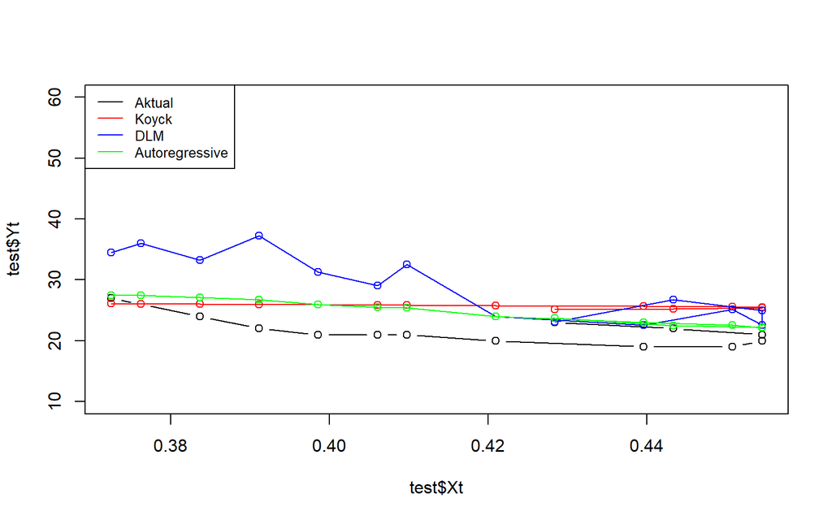

```r
par(mfrow=c(1,1))  # atur layout grafik tunggal

# plot data aktual
plot(test$Xt, test$Yt, type="b", col="black", ylim=c(10,60))

# tambahkan garis ramalan dari masing-masing model
points(test$Xt, fore.koyck$forecasts, col="red");   lines(test$Xt, fore.koyck$forecasts, col="red")
points(test$Xt, fore.dlm$forecasts, col="blue");    lines(test$Xt, fore.dlm$forecasts, col="blue")
points(test$Xt, fore.ardl$forecasts, col="green");  lines(test$Xt, fore.ardl$forecasts, col="green")

# legenda model
legend("topleft",
       c("Aktual", "Koyck","DLM", "Autoregressive"),
       lty=1, col=c("black","red","blue","green"), cex=0.8)
```

```r
length(test$Xt)
```

```
## [1] 14
```

```r
length(test$Yt)
```

```
## [1] 14
```

```r
length(fore.dlm$forecasts)
```

```
## [1] 14
```

# Uji Asumsi

## SSE

```r
deviance(model.dlm$model)
```

```
## [1] 0.3223414
```

## Autokorelasi

```r
dwtest(model.dlm$model)
```

```
##
##  Durbin-Watson test
##
## data:  model.dlm$model
## DW = 3.0682, p-value = 1
## alternative hypothesis: true autocorrelation is greater than 0
```

## Heterogenitas

```r
bptest(model.dlm$model)
```

```
##
##  studentized Breusch-Pagan test
##
## data:  model.dlm$model
## BP = 29.458, df = 28, p-value = 0.3896
```

## Kenormalan

```r
shapiro.test(residuals(model.dlm$model))
```

```
##
##  Shapiro-Wilk normality test
##
## data:  residuals(model.dlm$model)
## W = 0.97869, p-value = 0.7897
```

Berdasarkan uji asumsi tersebut, model DLM menyatakan bahwa semua asumsi sudah terpenuhi karena nilai p yang dihasilkan lebih besar dari 0.05 baik pada tidak adanya autokorelasi, ragam sisaan homogen, bahkan sisan menyebar normal.